# Inseason Bonneville Dam Chinook salmon passage predictions

2025-04-17

The cumulative adult Chinook passage at Bonneville Dam through April 16, 2025 is 1,836.

The 10-year (2015–2024 ) average proportion of the run that had passed Bonneville through April 16 is 1.5%. Based on the cumulative counts to date and this proportion, the expected total dam count is 124,472 adult Chinook.

### Current year

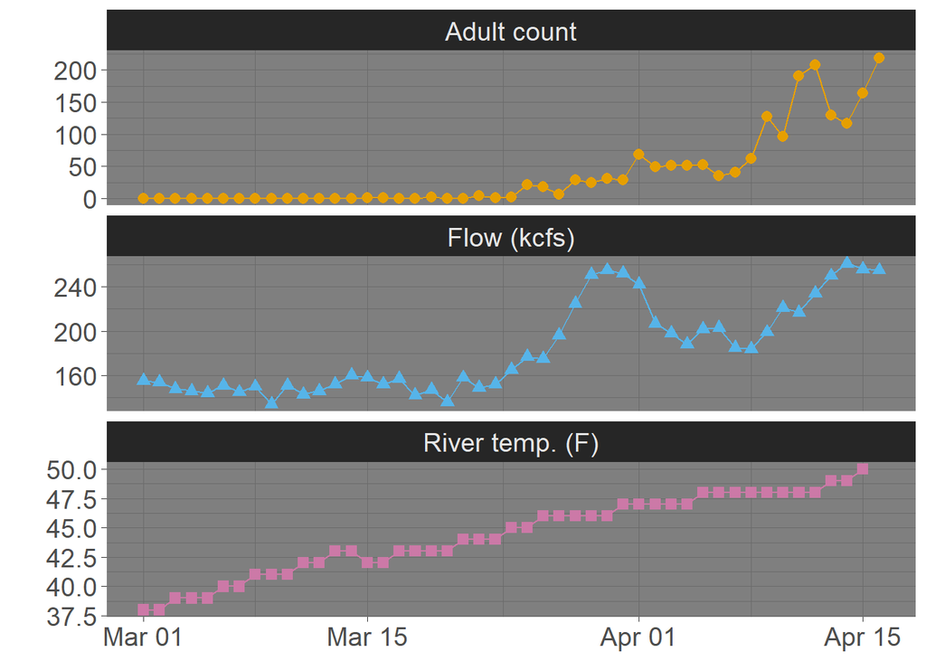

Daily adult chinook salmon counts, flow, and temeprature measurements taken at Bonneville Dam.

### Percent complete

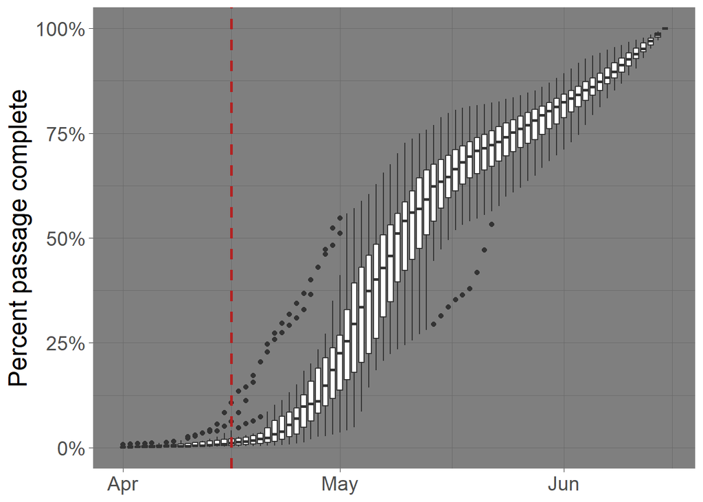

Percent of the run complete by date, 1995–2024.

### Prediction error

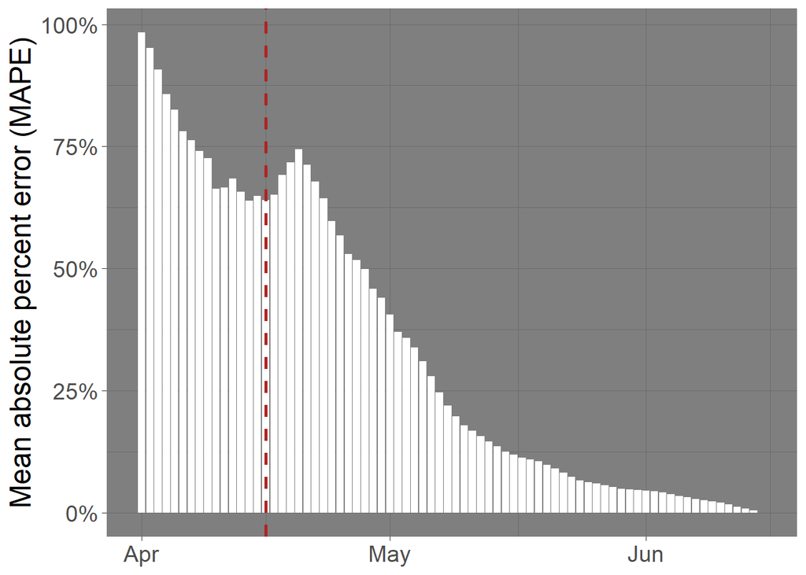

Mean absolute percent error (over 15 year retrospectiv) of predictions based on cumulative counts and 10-year average run timing, by day of year.

## Model predictions

### Prediction table

| Model | Pred | Lo 95 | Lo 50 | Hi 50 | Hi 95 | MAPE |
| --- | --- | --- | --- | --- | --- | --- |
| DLM | 142,261 | 91,545 | 122,236 | 165,566 | 221,074 | 18% |
| ARIMA | 136,647 | 65,617 | 105,936 | 176,694 | 290,539 | 17% |
| Joint_Lik | 128,518 | 73,124 | 105,848 | 156,043 | 225,876 | <sup>1</sup> — |
| 10-year ave. timing | 124,472 | 4,978 | 41,112 | 376,856 | 3,112,344 | 64% |

<sup>1</sup> I have not yet implemented a retrospective assessment of performance for the joint-likelihood model

### Prediction plot

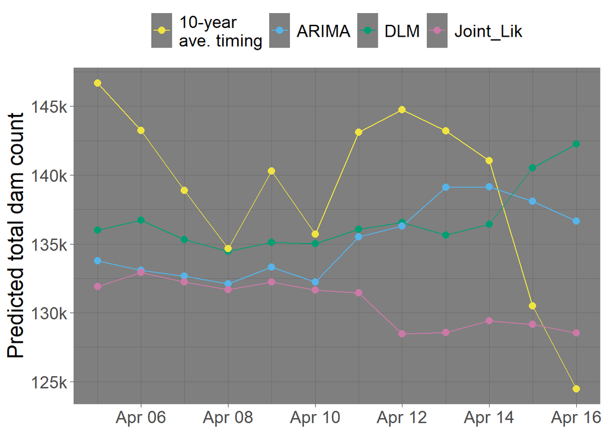

Daily predictions of total counts at Bonneville from different models

### Prediction interval plot

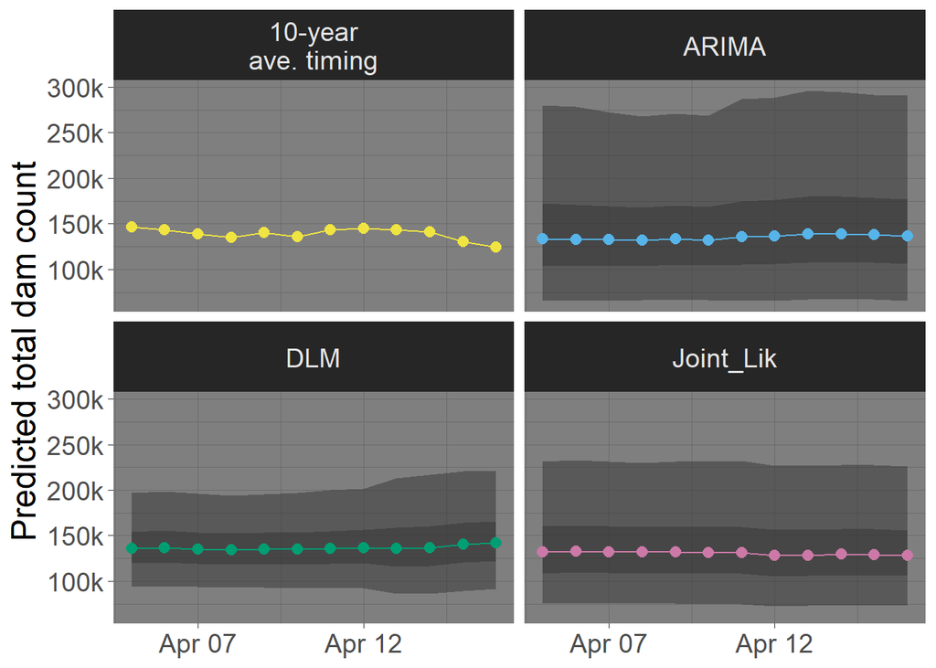

Daily predictions and prediction intervals (95% and 50%). Pridiction intervals that are >250% or <40% of the prediction are not shown.

### Covariate effects

Fitted coefficients, covariate values, and effects (coefficient * covariate) for the DLM and ARIMA models. Covariates are the log of the jack returns in the previous years, the log of the cumulative adult counts to date, and an interaction between the cumulative counts and a moving average of river discharge.

| Model<sup>1</sup> | coef intercept | coef log lag jack | coef log cum cnt | coef cnt by flow | covar log lag jack | covar log cum cnt | covar cnt by flow | effect log lag jack | effect log cum cnt | effect cnt by flow |
| --- | --- | --- | --- | --- | --- | --- | --- | --- | --- | --- |
| DLM | 0.33 | 0.64 | 0.42 | 0.06 | 0.63 | −0.68 | −0.23 | 0.40 | −0.29 | −0.01 |
| ARIMA | 7.28 | 0.33 | 0.19 | 0.05 | 0.63 | −0.69 | −0.21 | 0.21 | −0.13 | −0.01 |

<sup>1</sup> The response and the covariates are z-scored before fitting the DLM, but the response is not standardized for the ARIMA model

Fitted coefficient, covariate value, and effect (coefficient * covariate) for the log transformed and z-scaled moving average of river discharge in the linear predictor of the proportion of the run that is complete within the joint-likelihood model.

| Coefficient | Covariate | Effect |
| --- | --- | --- |
| −0.60 | 0.35 | −0.21 |

### Methods description

##### DLM

This is a penalized dynamic linear model fit with the [`Sibregresr` package](https://wdfw-fp.github.io/sibregresr/articles/Overview.html). The coefficients are the:

1. log-transformed total count of jacks at Bonneville Dam in the *previous* year,
2. log-transformed cumulative adult count at Bonneville Dam in the *current* year,
3. and interaction between an exponential moving average of river discharge and the cumulative adult count.

The prediction interval is based on the standard deviation (in lo-space) of forecasts from a 15-year retrospective. In other words, the root mean square error of the forecast error in log space from a 15-year retrospective is used as the standard deviation in a lognormal prediction interval.

#### ARIMA

This is an ensemble of ARIMA models fit with the [`SalmonForecasting` package](https://github.com/wdfw-fp/salmonforecast) (see README at the linked page for details). The covariates are the same as those described above for the DLM, and the prediction intervals are calculated in the same manner as well.

#### Joint likelihood

This is a version of a model that has been used for this purpose of in-season forecasting for several years. The proportion of the run that is complete on a given day is modeled with autoregressive (order 1) errors and an effect of the river discharge covariate. In this iteration, the pre-season forecast is fed in as a log-normal prior. The prediction interval is generated using the delta method. I have not yet implemented a retrospective assessment of performance because, in this version, the pre-season forecasts and prediction uncertainty need to be provided, and I have not pulled in the past 15 years’ forecasts.

## Average timing info

### 10-year average

#### Prediction

| Date | 10 Days Early | 9 Days Early | 8 Days Early | 7 Days Early | 6 Days Early | 5 Days Early | 4 Days Early | 3 Days Early | 2 Days Early | 1 Days Early | 10yr Average | 1 Days Late | 2 Days Late | 3 Days Late | 4 Days Late | 5 Days Late | 6 Days Late | 7 Days Late | 8 Days Late | 9 Days Late | 10 Days Late |
| --- | --- | --- | --- | --- | --- | --- | --- | --- | --- | --- | --- | --- | --- | --- | --- | --- | --- | --- | --- | --- | --- |
| 01-Apr | 34,270 | 40,193 | 47,162 | 55,208 | 63,704 | 71,317 | 78,781 | 88,631 | 99,718 | 113,357 | 127,755 | 146,714 | 170,949 | 190,203 | 235,421 | 283,291 | 337,659 | 388,075 | 437,389 | 506,343 | 569,429 |
| 02-Apr | 34,565 | 41,296 | 48,433 | 56,831 | 66,527 | 76,765 | 85,939 | 94,933 | 106,803 | 120,163 | 136,598 | 153,947 | 176,793 | 205,998 | 229,198 | 283,687 | 341,371 | 406,886 | 467,639 | 527,063 | 610,154 |
| 03-Apr | 36,447 | 40,806 | 48,752 | 57,178 | 67,092 | 78,538 | 90,625 | 101,455 | 112,074 | 126,086 | 141,859 | 161,262 | 181,744 | 208,715 | 243,192 | 270,581 | 334,908 | 403,008 | 480,352 | 552,073 | 622,228 |
| 04-Apr | 38,057 | 42,022 | 47,047 | 56,208 | 65,923 | 77,353 | 90,550 | 104,486 | 116,972 | 129,214 | 145,370 | 163,555 | 185,925 | 209,540 | 240,636 | 280,386 | 311,964 | 386,130 | 464,644 | 553,817 | 636,508 |
| 05-Apr | 35,916 | 43,202 | 47,703 | 53,408 | 63,808 | 74,836 | 87,812 | 102,793 | 118,613 | 132,787 | 146,685 | 165,025 | 185,668 | 211,063 | 237,870 | 273,170 | 318,295 | 354,143 | 438,336 | 527,466 | 628,696 |
| 06-Apr | 32,542 | 38,740 | 46,600 | 51,455 | 57,608 | 68,826 | 80,722 | 94,718 | 110,878 | 127,942 | 143,231 | 158,222 | 178,004 | 200,271 | 227,663 | 256,579 | 294,656 | 343,329 | 381,997 | 472,812 | 568,952 |
| 07-Apr | 28,797 | 35,321 | 42,050 | 50,580 | 55,850 | 62,529 | 74,705 | 87,617 | 102,809 | 120,348 | 138,870 | 155,465 | 171,736 | 193,209 | 217,378 | 247,110 | 278,495 | 319,824 | 372,655 | 414,626 | 513,198 |
| 08-Apr | 25,736 | 32,224 | 39,525 | 47,054 | 56,600 | 62,497 | 69,970 | 83,595 | 98,044 | 115,043 | 134,670 | 155,396 | 173,966 | 192,173 | 216,201 | 243,246 | 276,516 | 311,637 | 357,884 | 417,002 | 463,967 |
| 09-Apr | 24,584 | 31,387 | 39,299 | 48,202 | 57,384 | 69,026 | 76,218 | 85,332 | 101,949 | 119,570 | 140,302 | 164,238 | 189,514 | 212,161 | 234,366 | 263,669 | 296,651 | 337,226 | 380,058 | 436,459 | 508,557 |
| 10-Apr | 22,200 | 27,903 | 35,625 | 44,605 | 54,711 | 65,132 | 78,346 | 86,509 | 96,854 | 115,714 | 135,714 | 159,245 | 186,413 | 215,102 | 240,807 | 266,010 | 299,270 | 336,706 | 382,759 | 431,374 | 495,390 |
| 11-Apr | 23,198 | 27,454 | 34,508 | 44,057 | 55,162 | 67,659 | 80,548 | 96,889 | 106,984 | 119,777 | 143,102 | 167,835 | 196,935 | 230,533 | 266,012 | 297,801 | 328,969 | 370,100 | 416,397 | 473,350 | 533,471 |
| 12-Apr | 23,246 | 28,032 | 33,176 | 41,699 | 53,239 | 66,659 | 81,761 | 97,335 | 117,083 | 129,281 | 144,741 | 172,926 | 202,815 | 237,980 | 278,580 | 321,454 | 359,868 | 397,532 | 447,235 | 503,181 | 572,004 |
| 13-Apr | 22,471 | 25,751 | 31,054 | 36,752 | 46,194 | 58,978 | 73,844 | 90,574 | 107,828 | 129,703 | 143,217 | 160,343 | 191,567 | 224,677 | 263,633 | 308,610 | 356,104 | 398,660 | 440,383 | 495,445 | 557,421 |
| 14-Apr | 21,581 | 24,439 | 28,007 | 33,774 | 39,971 | 50,240 | 64,143 | 80,311 | 98,506 | 117,271 | 141,062 | 155,759 | 174,385 | 208,343 | 244,353 | 286,721 | 335,636 | 387,290 | 433,572 | 478,950 | 538,833 |
| 15-Apr | 21,454 | 24,017 | 27,198 | 31,168 | 37,586 | 44,482 | 55,911 | 71,382 | 89,376 | 109,625 | 130,507 | 156,984 | 173,340 | 194,068 | 231,859 | 271,933 | 319,083 | 373,519 | 431,004 | 482,509 | 533,009 |
| 16-Apr | 21,124 | 24,360 | 27,270 | 30,881 | 35,389 | 42,676 | 50,506 | 63,483 | 81,050 | 101,481 | 124,472 | 148,182 | 178,245 | 196,816 | 220,352 | 263,261 | 308,763 | 362,298 | 424,107 | 489,377 | 547,859 |

#### Proportion complete

| Date | 10 Days Early | 9 Days Early | 8 Days Early | 7 Days Early | 6 Days Early | 5 Days Early | 4 Days Early | 3 Days Early | 2 Days Early | 1 Days Early | 10yr Average | 1 Days Late | 2 Days Late | 3 Days Late | 4 Days Late | 5 Days Late | 6 Days Late | 7 Days Late | 8 Days Late | 9 Days Late | 10 Days Late |
| --- | --- | --- | --- | --- | --- | --- | --- | --- | --- | --- | --- | --- | --- | --- | --- | --- | --- | --- | --- | --- | --- |
| 01-Apr | 0.01 | 0.01 | 0.01 | 0.00 | 0.00 | 0.00 | 0.00 | 0.00 | 0.00 | 0.00 | 0.00 | 0.00 | 0.00 | 0.00 | 0.00 | 0.00 | 0.00 | 0.00 | 0.00 | 0.00 | 0.00 |
| 02-Apr | 0.01 | 0.01 | 0.01 | 0.01 | 0.00 | 0.00 | 0.00 | 0.00 | 0.00 | 0.00 | 0.00 | 0.00 | 0.00 | 0.00 | 0.00 | 0.00 | 0.00 | 0.00 | 0.00 | 0.00 | 0.00 |
| 03-Apr | 0.01 | 0.01 | 0.01 | 0.01 | 0.01 | 0.00 | 0.00 | 0.00 | 0.00 | 0.00 | 0.00 | 0.00 | 0.00 | 0.00 | 0.00 | 0.00 | 0.00 | 0.00 | 0.00 | 0.00 | 0.00 |
| 04-Apr | 0.01 | 0.01 | 0.01 | 0.01 | 0.01 | 0.01 | 0.00 | 0.00 | 0.00 | 0.00 | 0.00 | 0.00 | 0.00 | 0.00 | 0.00 | 0.00 | 0.00 | 0.00 | 0.00 | 0.00 | 0.00 |
| 05-Apr | 0.01 | 0.01 | 0.01 | 0.01 | 0.01 | 0.01 | 0.01 | 0.00 | 0.00 | 0.00 | 0.00 | 0.00 | 0.00 | 0.00 | 0.00 | 0.00 | 0.00 | 0.00 | 0.00 | 0.00 | 0.00 |
| 06-Apr | 0.01 | 0.01 | 0.01 | 0.01 | 0.01 | 0.01 | 0.01 | 0.01 | 0.00 | 0.00 | 0.00 | 0.00 | 0.00 | 0.00 | 0.00 | 0.00 | 0.00 | 0.00 | 0.00 | 0.00 | 0.00 |
| 07-Apr | 0.02 | 0.01 | 0.01 | 0.01 | 0.01 | 0.01 | 0.01 | 0.01 | 0.01 | 0.00 | 0.00 | 0.00 | 0.00 | 0.00 | 0.00 | 0.00 | 0.00 | 0.00 | 0.00 | 0.00 | 0.00 |
| 08-Apr | 0.02 | 0.02 | 0.01 | 0.01 | 0.01 | 0.01 | 0.01 | 0.01 | 0.01 | 0.01 | 0.00 | 0.00 | 0.00 | 0.00 | 0.00 | 0.00 | 0.00 | 0.00 | 0.00 | 0.00 | 0.00 |
| 09-Apr | 0.03 | 0.02 | 0.02 | 0.01 | 0.01 | 0.01 | 0.01 | 0.01 | 0.01 | 0.01 | 0.01 | 0.00 | 0.00 | 0.00 | 0.00 | 0.00 | 0.00 | 0.00 | 0.00 | 0.00 | 0.00 |
| 10-Apr | 0.04 | 0.03 | 0.02 | 0.02 | 0.01 | 0.01 | 0.01 | 0.01 | 0.01 | 0.01 | 0.01 | 0.01 | 0.00 | 0.00 | 0.00 | 0.00 | 0.00 | 0.00 | 0.00 | 0.00 | 0.00 |
| 11-Apr | 0.04 | 0.04 | 0.03 | 0.02 | 0.02 | 0.01 | 0.01 | 0.01 | 0.01 | 0.01 | 0.01 | 0.01 | 0.01 | 0.00 | 0.00 | 0.00 | 0.00 | 0.00 | 0.00 | 0.00 | 0.00 |
| 12-Apr | 0.05 | 0.04 | 0.04 | 0.03 | 0.02 | 0.02 | 0.01 | 0.01 | 0.01 | 0.01 | 0.01 | 0.01 | 0.01 | 0.01 | 0.00 | 0.00 | 0.00 | 0.00 | 0.00 | 0.00 | 0.00 |
| 13-Apr | 0.06 | 0.05 | 0.04 | 0.04 | 0.03 | 0.02 | 0.02 | 0.01 | 0.01 | 0.01 | 0.01 | 0.01 | 0.01 | 0.01 | 0.01 | 0.00 | 0.00 | 0.00 | 0.00 | 0.00 | 0.00 |
| 14-Apr | 0.07 | 0.06 | 0.05 | 0.04 | 0.04 | 0.03 | 0.02 | 0.02 | 0.01 | 0.01 | 0.01 | 0.01 | 0.01 | 0.01 | 0.01 | 0.01 | 0.00 | 0.00 | 0.00 | 0.00 | 0.00 |
| 15-Apr | 0.08 | 0.07 | 0.06 | 0.05 | 0.04 | 0.04 | 0.03 | 0.02 | 0.02 | 0.01 | 0.01 | 0.01 | 0.01 | 0.01 | 0.01 | 0.01 | 0.01 | 0.00 | 0.00 | 0.00 | 0.00 |
| 16-Apr | 0.09 | 0.08 | 0.07 | 0.06 | 0.05 | 0.04 | 0.04 | 0.03 | 0.02 | 0.02 | 0.01 | 0.01 | 0.01 | 0.01 | 0.01 | 0.01 | 0.01 | 0.01 | 0.00 | 0.00 | 0.00 |
| 17-Apr | 0.10 | 0.09 | 0.08 | 0.07 | 0.06 | 0.05 | 0.04 | 0.04 | 0.03 | 0.02 | 0.02 | 0.01 | 0.01 | 0.01 | 0.01 | 0.01 | 0.01 | 0.01 | 0.01 | 0.00 | 0.00 |
| 18-Apr | 0.12 | 0.10 | 0.09 | 0.08 | 0.07 | 0.06 | 0.05 | 0.04 | 0.04 | 0.03 | 0.02 | 0.02 | 0.01 | 0.01 | 0.01 | 0.01 | 0.01 | 0.01 | 0.01 | 0.01 | 0.00 |
| 19-Apr | 0.15 | 0.12 | 0.10 | 0.09 | 0.08 | 0.07 | 0.06 | 0.05 | 0.04 | 0.04 | 0.03 | 0.02 | 0.02 | 0.01 | 0.01 | 0.01 | 0.01 | 0.01 | 0.01 | 0.01 | 0.01 |
| 20-Apr | 0.17 | 0.15 | 0.12 | 0.10 | 0.09 | 0.08 | 0.07 | 0.06 | 0.05 | 0.04 | 0.04 | 0.03 | 0.02 | 0.02 | 0.01 | 0.01 | 0.01 | 0.01 | 0.01 | 0.01 | 0.01 |
| 21-Apr | 0.20 | 0.17 | 0.15 | 0.12 | 0.10 | 0.09 | 0.08 | 0.07 | 0.06 | 0.05 | 0.04 | 0.04 | 0.03 | 0.02 | 0.02 | 0.01 | 0.01 | 0.01 | 0.01 | 0.01 | 0.01 |
| 22-Apr | 0.23 | 0.20 | 0.17 | 0.15 | 0.12 | 0.10 | 0.09 | 0.08 | 0.07 | 0.06 | 0.05 | 0.04 | 0.04 | 0.03 | 0.02 | 0.02 | 0.01 | 0.01 | 0.01 | 0.01 | 0.01 |
| 23-Apr | 0.26 | 0.23 | 0.20 | 0.17 | 0.15 | 0.12 | 0.10 | 0.09 | 0.08 | 0.07 | 0.06 | 0.05 | 0.04 | 0.04 | 0.03 | 0.02 | 0.02 | 0.01 | 0.01 | 0.01 | 0.01 |
| 24-Apr | 0.29 | 0.26 | 0.23 | 0.20 | 0.17 | 0.15 | 0.12 | 0.10 | 0.09 | 0.08 | 0.07 | 0.06 | 0.05 | 0.04 | 0.04 | 0.03 | 0.02 | 0.02 | 0.01 | 0.01 | 0.01 |
| 25-Apr | 0.33 | 0.29 | 0.26 | 0.23 | 0.20 | 0.17 | 0.15 | 0.12 | 0.10 | 0.09 | 0.08 | 0.07 | 0.06 | 0.05 | 0.04 | 0.04 | 0.03 | 0.02 | 0.02 | 0.01 | 0.01 |
| 26-Apr | 0.35 | 0.33 | 0.29 | 0.26 | 0.23 | 0.20 | 0.17 | 0.15 | 0.12 | 0.10 | 0.09 | 0.08 | 0.07 | 0.06 | 0.05 | 0.04 | 0.04 | 0.03 | 0.02 | 0.02 | 0.01 |
| 27-Apr | 0.38 | 0.35 | 0.33 | 0.29 | 0.26 | 0.23 | 0.20 | 0.17 | 0.15 | 0.12 | 0.10 | 0.09 | 0.08 | 0.07 | 0.06 | 0.05 | 0.04 | 0.04 | 0.03 | 0.02 | 0.02 |
| 28-Apr | 0.41 | 0.38 | 0.35 | 0.33 | 0.29 | 0.26 | 0.23 | 0.20 | 0.17 | 0.15 | 0.12 | 0.10 | 0.09 | 0.08 | 0.07 | 0.06 | 0.05 | 0.04 | 0.04 | 0.03 | 0.02 |
| 29-Apr | 0.43 | 0.41 | 0.38 | 0.35 | 0.33 | 0.29 | 0.26 | 0.23 | 0.20 | 0.17 | 0.15 | 0.12 | 0.10 | 0.09 | 0.08 | 0.07 | 0.06 | 0.05 | 0.04 | 0.04 | 0.03 |
| 30-Apr | 0.46 | 0.43 | 0.41 | 0.38 | 0.35 | 0.33 | 0.29 | 0.26 | 0.23 | 0.20 | 0.17 | 0.15 | 0.12 | 0.10 | 0.09 | 0.08 | 0.07 | 0.06 | 0.05 | 0.04 | 0.04 |
| 01-May | 0.49 | 0.46 | 0.43 | 0.41 | 0.38 | 0.35 | 0.33 | 0.29 | 0.26 | 0.23 | 0.20 | 0.17 | 0.15 | 0.12 | 0.10 | 0.09 | 0.08 | 0.07 | 0.06 | 0.05 | 0.04 |
| 02-May | 0.51 | 0.49 | 0.46 | 0.43 | 0.41 | 0.38 | 0.35 | 0.33 | 0.29 | 0.26 | 0.23 | 0.20 | 0.17 | 0.15 | 0.12 | 0.10 | 0.09 | 0.08 | 0.07 | 0.06 | 0.05 |
| 03-May | 0.53 | 0.51 | 0.49 | 0.46 | 0.43 | 0.41 | 0.38 | 0.35 | 0.33 | 0.29 | 0.26 | 0.23 | 0.20 | 0.17 | 0.15 | 0.12 | 0.10 | 0.09 | 0.08 | 0.07 | 0.06 |
| 04-May | 0.55 | 0.53 | 0.51 | 0.49 | 0.46 | 0.43 | 0.41 | 0.38 | 0.35 | 0.33 | 0.29 | 0.26 | 0.23 | 0.20 | 0.17 | 0.15 | 0.12 | 0.10 | 0.09 | 0.08 | 0.07 |
| 05-May | 0.57 | 0.55 | 0.53 | 0.51 | 0.49 | 0.46 | 0.43 | 0.41 | 0.38 | 0.35 | 0.33 | 0.29 | 0.26 | 0.23 | 0.20 | 0.17 | 0.15 | 0.12 | 0.10 | 0.09 | 0.08 |
| 06-May | 0.59 | 0.57 | 0.55 | 0.53 | 0.51 | 0.49 | 0.46 | 0.43 | 0.41 | 0.38 | 0.35 | 0.33 | 0.29 | 0.26 | 0.23 | 0.20 | 0.17 | 0.15 | 0.12 | 0.10 | 0.09 |
| 07-May | 0.60 | 0.59 | 0.57 | 0.55 | 0.53 | 0.51 | 0.49 | 0.46 | 0.43 | 0.41 | 0.38 | 0.35 | 0.33 | 0.29 | 0.26 | 0.23 | 0.20 | 0.17 | 0.15 | 0.12 | 0.10 |
| 08-May | 0.62 | 0.60 | 0.59 | 0.57 | 0.55 | 0.53 | 0.51 | 0.49 | 0.46 | 0.43 | 0.41 | 0.38 | 0.35 | 0.33 | 0.29 | 0.26 | 0.23 | 0.20 | 0.17 | 0.15 | 0.12 |
| 09-May | 0.63 | 0.62 | 0.60 | 0.59 | 0.57 | 0.55 | 0.53 | 0.51 | 0.49 | 0.46 | 0.43 | 0.41 | 0.38 | 0.35 | 0.33 | 0.29 | 0.26 | 0.23 | 0.20 | 0.17 | 0.15 |
| 10-May | 0.65 | 0.63 | 0.62 | 0.60 | 0.59 | 0.57 | 0.55 | 0.53 | 0.51 | 0.49 | 0.46 | 0.43 | 0.41 | 0.38 | 0.35 | 0.33 | 0.29 | 0.26 | 0.23 | 0.20 | 0.17 |
| 11-May | 0.66 | 0.65 | 0.63 | 0.62 | 0.60 | 0.59 | 0.57 | 0.55 | 0.53 | 0.51 | 0.49 | 0.46 | 0.43 | 0.41 | 0.38 | 0.35 | 0.33 | 0.29 | 0.26 | 0.23 | 0.20 |
| 12-May | 0.68 | 0.66 | 0.65 | 0.63 | 0.62 | 0.60 | 0.59 | 0.57 | 0.55 | 0.53 | 0.51 | 0.49 | 0.46 | 0.43 | 0.41 | 0.38 | 0.35 | 0.33 | 0.29 | 0.26 | 0.23 |
| 13-May | 0.70 | 0.68 | 0.66 | 0.65 | 0.63 | 0.62 | 0.60 | 0.59 | 0.57 | 0.55 | 0.53 | 0.51 | 0.49 | 0.46 | 0.43 | 0.41 | 0.38 | 0.35 | 0.33 | 0.29 | 0.26 |
| 14-May | 0.71 | 0.70 | 0.68 | 0.66 | 0.65 | 0.63 | 0.62 | 0.60 | 0.59 | 0.57 | 0.55 | 0.53 | 0.51 | 0.49 | 0.46 | 0.43 | 0.41 | 0.38 | 0.35 | 0.33 | 0.29 |
| 15-May | 0.72 | 0.71 | 0.70 | 0.68 | 0.66 | 0.65 | 0.63 | 0.62 | 0.60 | 0.59 | 0.57 | 0.55 | 0.53 | 0.51 | 0.49 | 0.46 | 0.43 | 0.41 | 0.38 | 0.35 | 0.33 |
| 16-May | 0.73 | 0.72 | 0.71 | 0.70 | 0.68 | 0.66 | 0.65 | 0.63 | 0.62 | 0.60 | 0.59 | 0.57 | 0.55 | 0.53 | 0.51 | 0.49 | 0.46 | 0.43 | 0.41 | 0.38 | 0.35 |
| 17-May | 0.75 | 0.73 | 0.72 | 0.71 | 0.70 | 0.68 | 0.66 | 0.65 | 0.63 | 0.62 | 0.60 | 0.59 | 0.57 | 0.55 | 0.53 | 0.51 | 0.49 | 0.46 | 0.43 | 0.41 | 0.38 |
| 18-May | 0.76 | 0.75 | 0.73 | 0.72 | 0.71 | 0.70 | 0.68 | 0.66 | 0.65 | 0.63 | 0.62 | 0.60 | 0.59 | 0.57 | 0.55 | 0.53 | 0.51 | 0.49 | 0.46 | 0.43 | 0.41 |
| 19-May | 0.77 | 0.76 | 0.75 | 0.73 | 0.72 | 0.71 | 0.70 | 0.68 | 0.66 | 0.65 | 0.63 | 0.62 | 0.60 | 0.59 | 0.57 | 0.55 | 0.53 | 0.51 | 0.49 | 0.46 | 0.43 |
| 20-May | 0.78 | 0.77 | 0.76 | 0.75 | 0.73 | 0.72 | 0.71 | 0.70 | 0.68 | 0.66 | 0.65 | 0.63 | 0.62 | 0.60 | 0.59 | 0.57 | 0.55 | 0.53 | 0.51 | 0.49 | 0.46 |
| 21-May | 0.79 | 0.78 | 0.77 | 0.76 | 0.75 | 0.73 | 0.72 | 0.71 | 0.70 | 0.68 | 0.66 | 0.65 | 0.63 | 0.62 | 0.60 | 0.59 | 0.57 | 0.55 | 0.53 | 0.51 | 0.49 |
| 22-May | 0.80 | 0.79 | 0.78 | 0.77 | 0.76 | 0.75 | 0.73 | 0.72 | 0.71 | 0.70 | 0.68 | 0.66 | 0.65 | 0.63 | 0.62 | 0.60 | 0.59 | 0.57 | 0.55 | 0.53 | 0.51 |
| 23-May | 0.82 | 0.80 | 0.79 | 0.78 | 0.77 | 0.76 | 0.75 | 0.73 | 0.72 | 0.71 | 0.70 | 0.68 | 0.66 | 0.65 | 0.63 | 0.62 | 0.60 | 0.59 | 0.57 | 0.55 | 0.53 |
| 24-May | 0.83 | 0.82 | 0.80 | 0.79 | 0.78 | 0.77 | 0.76 | 0.75 | 0.73 | 0.72 | 0.71 | 0.70 | 0.68 | 0.66 | 0.65 | 0.63 | 0.62 | 0.60 | 0.59 | 0.57 | 0.55 |
| 25-May | 0.84 | 0.83 | 0.82 | 0.80 | 0.79 | 0.78 | 0.77 | 0.76 | 0.75 | 0.73 | 0.72 | 0.71 | 0.70 | 0.68 | 0.66 | 0.65 | 0.63 | 0.62 | 0.60 | 0.59 | 0.57 |
| 26-May | 0.85 | 0.84 | 0.83 | 0.82 | 0.80 | 0.79 | 0.78 | 0.77 | 0.76 | 0.75 | 0.73 | 0.72 | 0.71 | 0.70 | 0.68 | 0.66 | 0.65 | 0.63 | 0.62 | 0.60 | 0.59 |
| 27-May | 0.86 | 0.85 | 0.84 | 0.83 | 0.82 | 0.80 | 0.79 | 0.78 | 0.77 | 0.76 | 0.75 | 0.73 | 0.72 | 0.71 | 0.70 | 0.68 | 0.66 | 0.65 | 0.63 | 0.62 | 0.60 |
| 28-May | 0.88 | 0.86 | 0.85 | 0.84 | 0.83 | 0.82 | 0.80 | 0.79 | 0.78 | 0.77 | 0.76 | 0.75 | 0.73 | 0.72 | 0.71 | 0.70 | 0.68 | 0.66 | 0.65 | 0.63 | 0.62 |
| 29-May | 0.89 | 0.88 | 0.86 | 0.85 | 0.84 | 0.83 | 0.82 | 0.80 | 0.79 | 0.78 | 0.77 | 0.76 | 0.75 | 0.73 | 0.72 | 0.71 | 0.70 | 0.68 | 0.66 | 0.65 | 0.63 |
| 30-May | 0.91 | 0.89 | 0.88 | 0.86 | 0.85 | 0.84 | 0.83 | 0.82 | 0.80 | 0.79 | 0.78 | 0.77 | 0.76 | 0.75 | 0.73 | 0.72 | 0.71 | 0.70 | 0.68 | 0.66 | 0.65 |
| 31-May | 0.92 | 0.91 | 0.89 | 0.88 | 0.86 | 0.85 | 0.84 | 0.83 | 0.82 | 0.80 | 0.79 | 0.78 | 0.77 | 0.76 | 0.75 | 0.73 | 0.72 | 0.71 | 0.70 | 0.68 | 0.66 |
| 01-Jun | 0.94 | 0.92 | 0.91 | 0.89 | 0.88 | 0.86 | 0.85 | 0.84 | 0.83 | 0.82 | 0.80 | 0.79 | 0.78 | 0.77 | 0.76 | 0.75 | 0.73 | 0.72 | 0.71 | 0.70 | 0.68 |
| 02-Jun | 0.95 | 0.94 | 0.92 | 0.91 | 0.89 | 0.88 | 0.86 | 0.85 | 0.84 | 0.83 | 0.82 | 0.80 | 0.79 | 0.78 | 0.77 | 0.76 | 0.75 | 0.73 | 0.72 | 0.71 | 0.70 |
| 03-Jun | 0.97 | 0.95 | 0.94 | 0.92 | 0.91 | 0.89 | 0.88 | 0.86 | 0.85 | 0.84 | 0.83 | 0.82 | 0.80 | 0.79 | 0.78 | 0.77 | 0.76 | 0.75 | 0.73 | 0.72 | 0.71 |
| 04-Jun | 0.98 | 0.97 | 0.95 | 0.94 | 0.92 | 0.91 | 0.89 | 0.88 | 0.86 | 0.85 | 0.84 | 0.83 | 0.82 | 0.80 | 0.79 | 0.78 | 0.77 | 0.76 | 0.75 | 0.73 | 0.72 |
| 05-Jun | 1.00 | 0.98 | 0.97 | 0.95 | 0.94 | 0.92 | 0.91 | 0.89 | 0.88 | 0.86 | 0.85 | 0.84 | 0.83 | 0.82 | 0.80 | 0.79 | 0.78 | 0.77 | 0.76 | 0.75 | 0.73 |
| 06-Jun | NA | 1.00 | 0.98 | 0.97 | 0.95 | 0.94 | 0.92 | 0.91 | 0.89 | 0.88 | 0.86 | 0.85 | 0.84 | 0.83 | 0.82 | 0.80 | 0.79 | 0.78 | 0.77 | 0.76 | 0.75 |
| 07-Jun | NA | NA | 1.00 | 0.98 | 0.97 | 0.95 | 0.94 | 0.92 | 0.91 | 0.89 | 0.88 | 0.86 | 0.85 | 0.84 | 0.83 | 0.82 | 0.80 | 0.79 | 0.78 | 0.77 | 0.76 |
| 08-Jun | NA | NA | NA | 1.00 | 0.98 | 0.97 | 0.95 | 0.94 | 0.92 | 0.91 | 0.89 | 0.88 | 0.86 | 0.85 | 0.84 | 0.83 | 0.82 | 0.80 | 0.79 | 0.78 | 0.77 |
| 09-Jun | NA | NA | NA | NA | 1.00 | 0.98 | 0.97 | 0.95 | 0.94 | 0.92 | 0.91 | 0.89 | 0.88 | 0.86 | 0.85 | 0.84 | 0.83 | 0.82 | 0.80 | 0.79 | 0.78 |
| 10-Jun | NA | NA | NA | NA | NA | 1.00 | 0.98 | 0.97 | 0.95 | 0.94 | 0.92 | 0.91 | 0.89 | 0.88 | 0.86 | 0.85 | 0.84 | 0.83 | 0.82 | 0.80 | 0.79 |
| 11-Jun | NA | NA | NA | NA | NA | NA | 1.00 | 0.98 | 0.97 | 0.95 | 0.94 | 0.92 | 0.91 | 0.89 | 0.88 | 0.86 | 0.85 | 0.84 | 0.83 | 0.82 | 0.80 |
| 12-Jun | NA | NA | NA | NA | NA | NA | NA | 1.00 | 0.98 | 0.97 | 0.95 | 0.94 | 0.92 | 0.91 | 0.89 | 0.88 | 0.86 | 0.85 | 0.84 | 0.83 | 0.82 |
| 13-Jun | NA | NA | NA | NA | NA | NA | NA | NA | 1.00 | 0.98 | 0.97 | 0.95 | 0.94 | 0.92 | 0.91 | 0.89 | 0.88 | 0.86 | 0.85 | 0.84 | 0.83 |
| 14-Jun | NA | NA | NA | NA | NA | NA | NA | NA | NA | 1.00 | 0.98 | 0.97 | 0.95 | 0.94 | 0.92 | 0.91 | 0.89 | 0.88 | 0.86 | 0.85 | 0.84 |
| 15-Jun | NA | NA | NA | NA | NA | NA | NA | NA | NA | NA | 1.00 | 0.98 | 0.97 | 0.95 | 0.94 | 0.92 | 0.91 | 0.89 | 0.88 | 0.86 | 0.85 |

### 5-year average

#### Prediction

| Date | 10 Days Early | 9 Days Early | 8 Days Early | 7 Days Early | 6 Days Early | 5 Days Early | 4 Days Early | 3 Days Early | 2 Days Early | 1 Days Early | 5yr Average | 1 Days Late | 2 Days Late | 3 Days Late | 4 Days Late | 5 Days Late | 6 Days Late | 7 Days Late | 8 Days Late | 9 Days Late | 10 Days Late |
| --- | --- | --- | --- | --- | --- | --- | --- | --- | --- | --- | --- | --- | --- | --- | --- | --- | --- | --- | --- | --- | --- |
| 01-Apr | 50,081 | 55,005 | 62,167 | 68,884 | 76,078 | 82,503 | 90,838 | 102,193 | 116,119 | 127,209 | 137,100 | 154,575 | 172,556 | 190,585 | 235,997 | 280,078 | 352,821 | 420,632 | 485,662 | 597,765 | 717,838 |
| 02-Apr | 53,002 | 60,349 | 66,282 | 74,913 | 83,006 | 91,676 | 99,417 | 109,462 | 123,144 | 139,926 | 153,290 | 165,209 | 186,267 | 207,933 | 229,659 | 284,381 | 337,500 | 425,156 | 506,871 | 585,232 | 720,319 |
| 03-Apr | 55,500 | 62,572 | 71,245 | 78,249 | 88,439 | 97,993 | 108,229 | 117,368 | 129,226 | 145,379 | 165,190 | 180,967 | 195,038 | 219,898 | 245,477 | 271,125 | 335,728 | 398,438 | 501,920 | 598,389 | 690,899 |
| 04-Apr | 56,578 | 63,988 | 72,142 | 82,142 | 90,217 | 101,965 | 112,981 | 124,781 | 135,318 | 148,990 | 167,613 | 190,454 | 208,644 | 224,867 | 253,530 | 283,021 | 312,592 | 387,074 | 459,375 | 578,685 | 689,907 |
| 05-Apr | 54,556 | 64,228 | 72,639 | 81,896 | 93,248 | 102,415 | 115,751 | 128,256 | 141,652 | 153,614 | 169,134 | 190,275 | 216,204 | 236,854 | 255,270 | 287,808 | 321,286 | 354,855 | 439,408 | 521,485 | 656,925 |
| 06-Apr | 48,325 | 58,847 | 69,279 | 78,353 | 88,337 | 100,582 | 110,470 | 124,855 | 138,344 | 152,793 | 165,696 | 182,437 | 205,241 | 233,209 | 255,483 | 275,348 | 310,444 | 346,556 | 382,765 | 473,968 | 562,501 |
| 07-Apr | 43,987 | 52,452 | 63,874 | 75,197 | 85,045 | 95,883 | 109,173 | 119,906 | 135,519 | 150,161 | 165,845 | 179,849 | 198,020 | 222,772 | 253,129 | 277,305 | 298,867 | 336,962 | 376,157 | 415,460 | 514,453 |
| 08-Apr | 42,005 | 49,222 | 58,694 | 71,475 | 84,146 | 95,166 | 107,293 | 122,165 | 134,175 | 151,646 | 168,030 | 185,580 | 201,251 | 221,584 | 249,282 | 283,252 | 310,305 | 334,433 | 377,061 | 420,921 | 464,900 |
| 09-Apr | 42,536 | 51,227 | 60,029 | 71,581 | 87,167 | 102,620 | 116,060 | 130,849 | 148,987 | 163,633 | 184,941 | 204,922 | 226,325 | 245,437 | 270,234 | 304,013 | 345,441 | 378,434 | 407,859 | 459,846 | 513,336 |
| 10-Apr | 40,342 | 48,279 | 58,144 | 68,134 | 81,246 | 98,937 | 116,476 | 131,730 | 148,517 | 169,103 | 185,727 | 209,912 | 232,590 | 256,884 | 278,576 | 306,721 | 345,061 | 392,083 | 429,530 | 462,928 | 521,935 |
| 11-Apr | 40,546 | 49,890 | 59,706 | 71,905 | 84,260 | 100,475 | 122,353 | 144,043 | 162,908 | 183,668 | 209,126 | 229,685 | 259,593 | 287,640 | 317,683 | 344,509 | 379,316 | 426,730 | 484,881 | 531,191 | 572,494 |
| 12-Apr | 38,318 | 48,996 | 60,288 | 72,150 | 86,891 | 101,821 | 121,415 | 147,854 | 174,064 | 196,861 | 221,947 | 252,712 | 277,555 | 313,697 | 347,589 | 383,894 | 416,310 | 458,372 | 515,667 | 585,938 | 641,900 |
| 13-Apr | 33,148 | 42,449 | 54,278 | 66,786 | 79,927 | 96,258 | 112,797 | 134,503 | 163,791 | 192,828 | 218,081 | 245,872 | 279,953 | 307,474 | 347,512 | 385,057 | 425,275 | 461,186 | 507,782 | 571,253 | 649,099 |
| 14-Apr | 28,921 | 36,051 | 46,166 | 59,031 | 72,635 | 86,927 | 104,687 | 122,675 | 146,282 | 178,135 | 209,714 | 237,180 | 267,404 | 304,470 | 334,401 | 377,945 | 418,778 | 462,519 | 501,575 | 552,251 | 621,281 |
| 15-Apr | 26,899 | 32,185 | 40,120 | 51,377 | 65,694 | 80,833 | 96,738 | 116,503 | 136,522 | 162,793 | 198,242 | 233,385 | 263,950 | 297,586 | 338,835 | 372,145 | 420,604 | 466,045 | 514,723 | 558,187 | 614,583 |
| 16-Apr | 23,920 | 30,543 | 36,544 | 45,554 | 58,335 | 74,591 | 91,781 | 109,840 | 132,282 | 155,011 | 184,841 | 225,091 | 264,994 | 299,698 | 337,890 | 384,725 | 422,546 | 477,569 | 529,165 | 584,435 | 633,786 |

#### Proportion complete

| Date | 10 Days Early | 9 Days Early | 8 Days Early | 7 Days Early | 6 Days Early | 5 Days Early | 4 Days Early | 3 Days Early | 2 Days Early | 1 Days Early | 5yr Average | 1 Days Late | 2 Days Late | 3 Days Late | 4 Days Late | 5 Days Late | 6 Days Late | 7 Days Late | 8 Days Late | 9 Days Late | 10 Days Late |
| --- | --- | --- | --- | --- | --- | --- | --- | --- | --- | --- | --- | --- | --- | --- | --- | --- | --- | --- | --- | --- | --- |
| 01-Apr | 0.00 | 0.00 | 0.00 | 0.00 | 0.00 | 0.00 | 0.00 | 0.00 | 0.00 | 0.00 | 0.00 | 0.00 | 0.00 | 0.00 | 0.00 | 0.00 | 0.00 | 0.00 | 0.00 | 0.00 | 0.00 |
| 02-Apr | 0.01 | 0.00 | 0.00 | 0.00 | 0.00 | 0.00 | 0.00 | 0.00 | 0.00 | 0.00 | 0.00 | 0.00 | 0.00 | 0.00 | 0.00 | 0.00 | 0.00 | 0.00 | 0.00 | 0.00 | 0.00 |
| 03-Apr | 0.01 | 0.01 | 0.00 | 0.00 | 0.00 | 0.00 | 0.00 | 0.00 | 0.00 | 0.00 | 0.00 | 0.00 | 0.00 | 0.00 | 0.00 | 0.00 | 0.00 | 0.00 | 0.00 | 0.00 | 0.00 |
| 04-Apr | 0.01 | 0.01 | 0.01 | 0.00 | 0.00 | 0.00 | 0.00 | 0.00 | 0.00 | 0.00 | 0.00 | 0.00 | 0.00 | 0.00 | 0.00 | 0.00 | 0.00 | 0.00 | 0.00 | 0.00 | 0.00 |
| 05-Apr | 0.01 | 0.01 | 0.01 | 0.01 | 0.00 | 0.00 | 0.00 | 0.00 | 0.00 | 0.00 | 0.00 | 0.00 | 0.00 | 0.00 | 0.00 | 0.00 | 0.00 | 0.00 | 0.00 | 0.00 | 0.00 |
| 06-Apr | 0.01 | 0.01 | 0.01 | 0.01 | 0.01 | 0.00 | 0.00 | 0.00 | 0.00 | 0.00 | 0.00 | 0.00 | 0.00 | 0.00 | 0.00 | 0.00 | 0.00 | 0.00 | 0.00 | 0.00 | 0.00 |
| 07-Apr | 0.01 | 0.01 | 0.01 | 0.01 | 0.01 | 0.01 | 0.00 | 0.00 | 0.00 | 0.00 | 0.00 | 0.00 | 0.00 | 0.00 | 0.00 | 0.00 | 0.00 | 0.00 | 0.00 | 0.00 | 0.00 |
| 08-Apr | 0.01 | 0.01 | 0.01 | 0.01 | 0.01 | 0.01 | 0.01 | 0.00 | 0.00 | 0.00 | 0.00 | 0.00 | 0.00 | 0.00 | 0.00 | 0.00 | 0.00 | 0.00 | 0.00 | 0.00 | 0.00 |
| 09-Apr | 0.02 | 0.01 | 0.01 | 0.01 | 0.01 | 0.01 | 0.01 | 0.01 | 0.00 | 0.00 | 0.00 | 0.00 | 0.00 | 0.00 | 0.00 | 0.00 | 0.00 | 0.00 | 0.00 | 0.00 | 0.00 |
| 10-Apr | 0.02 | 0.02 | 0.01 | 0.01 | 0.01 | 0.01 | 0.01 | 0.01 | 0.01 | 0.00 | 0.00 | 0.00 | 0.00 | 0.00 | 0.00 | 0.00 | 0.00 | 0.00 | 0.00 | 0.00 | 0.00 |
| 11-Apr | 0.02 | 0.02 | 0.02 | 0.01 | 0.01 | 0.01 | 0.01 | 0.01 | 0.01 | 0.01 | 0.00 | 0.00 | 0.00 | 0.00 | 0.00 | 0.00 | 0.00 | 0.00 | 0.00 | 0.00 | 0.00 |
| 12-Apr | 0.03 | 0.02 | 0.02 | 0.02 | 0.01 | 0.01 | 0.01 | 0.01 | 0.01 | 0.01 | 0.01 | 0.00 | 0.00 | 0.00 | 0.00 | 0.00 | 0.00 | 0.00 | 0.00 | 0.00 | 0.00 |
| 13-Apr | 0.04 | 0.03 | 0.02 | 0.02 | 0.02 | 0.01 | 0.01 | 0.01 | 0.01 | 0.01 | 0.01 | 0.01 | 0.00 | 0.00 | 0.00 | 0.00 | 0.00 | 0.00 | 0.00 | 0.00 | 0.00 |
| 14-Apr | 0.05 | 0.04 | 0.03 | 0.02 | 0.02 | 0.02 | 0.01 | 0.01 | 0.01 | 0.01 | 0.01 | 0.01 | 0.01 | 0.00 | 0.00 | 0.00 | 0.00 | 0.00 | 0.00 | 0.00 | 0.00 |
| 15-Apr | 0.06 | 0.05 | 0.04 | 0.03 | 0.02 | 0.02 | 0.02 | 0.01 | 0.01 | 0.01 | 0.01 | 0.01 | 0.01 | 0.01 | 0.00 | 0.00 | 0.00 | 0.00 | 0.00 | 0.00 | 0.00 |
| 16-Apr | 0.08 | 0.06 | 0.05 | 0.04 | 0.03 | 0.02 | 0.02 | 0.02 | 0.01 | 0.01 | 0.01 | 0.01 | 0.01 | 0.01 | 0.01 | 0.00 | 0.00 | 0.00 | 0.00 | 0.00 | 0.00 |
| 17-Apr | 0.09 | 0.08 | 0.06 | 0.05 | 0.04 | 0.03 | 0.02 | 0.02 | 0.02 | 0.01 | 0.01 | 0.01 | 0.01 | 0.01 | 0.01 | 0.01 | 0.00 | 0.00 | 0.00 | 0.00 | 0.00 |
| 18-Apr | 0.12 | 0.09 | 0.08 | 0.06 | 0.05 | 0.04 | 0.03 | 0.02 | 0.02 | 0.02 | 0.01 | 0.01 | 0.01 | 0.01 | 0.01 | 0.01 | 0.01 | 0.00 | 0.00 | 0.00 | 0.00 |
| 19-Apr | 0.14 | 0.12 | 0.09 | 0.08 | 0.06 | 0.05 | 0.04 | 0.03 | 0.02 | 0.02 | 0.02 | 0.01 | 0.01 | 0.01 | 0.01 | 0.01 | 0.01 | 0.01 | 0.00 | 0.00 | 0.00 |
| 20-Apr | 0.17 | 0.14 | 0.12 | 0.09 | 0.08 | 0.06 | 0.05 | 0.04 | 0.03 | 0.02 | 0.02 | 0.02 | 0.01 | 0.01 | 0.01 | 0.01 | 0.01 | 0.01 | 0.01 | 0.00 | 0.00 |
| 21-Apr | 0.20 | 0.17 | 0.14 | 0.12 | 0.09 | 0.08 | 0.06 | 0.05 | 0.04 | 0.03 | 0.02 | 0.02 | 0.02 | 0.01 | 0.01 | 0.01 | 0.01 | 0.01 | 0.01 | 0.01 | 0.00 |
| 22-Apr | 0.23 | 0.20 | 0.17 | 0.14 | 0.12 | 0.09 | 0.08 | 0.06 | 0.05 | 0.04 | 0.03 | 0.02 | 0.02 | 0.02 | 0.01 | 0.01 | 0.01 | 0.01 | 0.01 | 0.01 | 0.01 |
| 23-Apr | 0.26 | 0.23 | 0.20 | 0.17 | 0.14 | 0.12 | 0.09 | 0.08 | 0.06 | 0.05 | 0.04 | 0.03 | 0.02 | 0.02 | 0.02 | 0.01 | 0.01 | 0.01 | 0.01 | 0.01 | 0.01 |
| 24-Apr | 0.29 | 0.26 | 0.23 | 0.20 | 0.17 | 0.14 | 0.12 | 0.09 | 0.08 | 0.06 | 0.05 | 0.04 | 0.03 | 0.02 | 0.02 | 0.02 | 0.01 | 0.01 | 0.01 | 0.01 | 0.01 |
| 25-Apr | 0.32 | 0.29 | 0.26 | 0.23 | 0.20 | 0.17 | 0.14 | 0.12 | 0.09 | 0.08 | 0.06 | 0.05 | 0.04 | 0.03 | 0.02 | 0.02 | 0.02 | 0.01 | 0.01 | 0.01 | 0.01 |
| 26-Apr | 0.35 | 0.32 | 0.29 | 0.26 | 0.23 | 0.20 | 0.17 | 0.14 | 0.12 | 0.09 | 0.08 | 0.06 | 0.05 | 0.04 | 0.03 | 0.02 | 0.02 | 0.02 | 0.01 | 0.01 | 0.01 |
| 27-Apr | 0.36 | 0.35 | 0.32 | 0.29 | 0.26 | 0.23 | 0.20 | 0.17 | 0.14 | 0.12 | 0.09 | 0.08 | 0.06 | 0.05 | 0.04 | 0.03 | 0.02 | 0.02 | 0.02 | 0.01 | 0.01 |
| 28-Apr | 0.39 | 0.36 | 0.35 | 0.32 | 0.29 | 0.26 | 0.23 | 0.20 | 0.17 | 0.14 | 0.12 | 0.09 | 0.08 | 0.06 | 0.05 | 0.04 | 0.03 | 0.02 | 0.02 | 0.02 | 0.01 |
| 29-Apr | 0.42 | 0.39 | 0.36 | 0.35 | 0.32 | 0.29 | 0.26 | 0.23 | 0.20 | 0.17 | 0.14 | 0.12 | 0.09 | 0.08 | 0.06 | 0.05 | 0.04 | 0.03 | 0.02 | 0.02 | 0.02 |
| 30-Apr | 0.46 | 0.42 | 0.39 | 0.36 | 0.35 | 0.32 | 0.29 | 0.26 | 0.23 | 0.20 | 0.17 | 0.14 | 0.12 | 0.09 | 0.08 | 0.06 | 0.05 | 0.04 | 0.03 | 0.02 | 0.02 |
| 01-May | 0.49 | 0.46 | 0.42 | 0.39 | 0.36 | 0.35 | 0.32 | 0.29 | 0.26 | 0.23 | 0.20 | 0.17 | 0.14 | 0.12 | 0.09 | 0.08 | 0.06 | 0.05 | 0.04 | 0.03 | 0.02 |
| 02-May | 0.52 | 0.49 | 0.46 | 0.42 | 0.39 | 0.36 | 0.35 | 0.32 | 0.29 | 0.26 | 0.23 | 0.20 | 0.17 | 0.14 | 0.12 | 0.09 | 0.08 | 0.06 | 0.05 | 0.04 | 0.03 |
| 03-May | 0.55 | 0.52 | 0.49 | 0.46 | 0.42 | 0.39 | 0.36 | 0.35 | 0.32 | 0.29 | 0.26 | 0.23 | 0.20 | 0.17 | 0.14 | 0.12 | 0.09 | 0.08 | 0.06 | 0.05 | 0.04 |
| 04-May | 0.57 | 0.55 | 0.52 | 0.49 | 0.46 | 0.42 | 0.39 | 0.36 | 0.35 | 0.32 | 0.29 | 0.26 | 0.23 | 0.20 | 0.17 | 0.14 | 0.12 | 0.09 | 0.08 | 0.06 | 0.05 |
| 05-May | 0.59 | 0.57 | 0.55 | 0.52 | 0.49 | 0.46 | 0.42 | 0.39 | 0.36 | 0.35 | 0.32 | 0.29 | 0.26 | 0.23 | 0.20 | 0.17 | 0.14 | 0.12 | 0.09 | 0.08 | 0.06 |
| 06-May | 0.62 | 0.59 | 0.57 | 0.55 | 0.52 | 0.49 | 0.46 | 0.42 | 0.39 | 0.36 | 0.35 | 0.32 | 0.29 | 0.26 | 0.23 | 0.20 | 0.17 | 0.14 | 0.12 | 0.09 | 0.08 |
| 07-May | 0.63 | 0.62 | 0.59 | 0.57 | 0.55 | 0.52 | 0.49 | 0.46 | 0.42 | 0.39 | 0.36 | 0.35 | 0.32 | 0.29 | 0.26 | 0.23 | 0.20 | 0.17 | 0.14 | 0.12 | 0.09 |
| 08-May | 0.65 | 0.63 | 0.62 | 0.59 | 0.57 | 0.55 | 0.52 | 0.49 | 0.46 | 0.42 | 0.39 | 0.36 | 0.35 | 0.32 | 0.29 | 0.26 | 0.23 | 0.20 | 0.17 | 0.14 | 0.12 |
| 09-May | 0.66 | 0.65 | 0.63 | 0.62 | 0.59 | 0.57 | 0.55 | 0.52 | 0.49 | 0.46 | 0.42 | 0.39 | 0.36 | 0.35 | 0.32 | 0.29 | 0.26 | 0.23 | 0.20 | 0.17 | 0.14 |
| 10-May | 0.67 | 0.66 | 0.65 | 0.63 | 0.62 | 0.59 | 0.57 | 0.55 | 0.52 | 0.49 | 0.46 | 0.42 | 0.39 | 0.36 | 0.35 | 0.32 | 0.29 | 0.26 | 0.23 | 0.20 | 0.17 |
| 11-May | 0.68 | 0.67 | 0.66 | 0.65 | 0.63 | 0.62 | 0.59 | 0.57 | 0.55 | 0.52 | 0.49 | 0.46 | 0.42 | 0.39 | 0.36 | 0.35 | 0.32 | 0.29 | 0.26 | 0.23 | 0.20 |
| 12-May | 0.69 | 0.68 | 0.67 | 0.66 | 0.65 | 0.63 | 0.62 | 0.59 | 0.57 | 0.55 | 0.52 | 0.49 | 0.46 | 0.42 | 0.39 | 0.36 | 0.35 | 0.32 | 0.29 | 0.26 | 0.23 |
| 13-May | 0.70 | 0.69 | 0.68 | 0.67 | 0.66 | 0.65 | 0.63 | 0.62 | 0.59 | 0.57 | 0.55 | 0.52 | 0.49 | 0.46 | 0.42 | 0.39 | 0.36 | 0.35 | 0.32 | 0.29 | 0.26 |
| 14-May | 0.71 | 0.70 | 0.69 | 0.68 | 0.67 | 0.66 | 0.65 | 0.63 | 0.62 | 0.59 | 0.57 | 0.55 | 0.52 | 0.49 | 0.46 | 0.42 | 0.39 | 0.36 | 0.35 | 0.32 | 0.29 |
| 15-May | 0.72 | 0.71 | 0.70 | 0.69 | 0.68 | 0.67 | 0.66 | 0.65 | 0.63 | 0.62 | 0.59 | 0.57 | 0.55 | 0.52 | 0.49 | 0.46 | 0.42 | 0.39 | 0.36 | 0.35 | 0.32 |
| 16-May | 0.73 | 0.72 | 0.71 | 0.70 | 0.69 | 0.68 | 0.67 | 0.66 | 0.65 | 0.63 | 0.62 | 0.59 | 0.57 | 0.55 | 0.52 | 0.49 | 0.46 | 0.42 | 0.39 | 0.36 | 0.35 |
| 17-May | 0.75 | 0.73 | 0.72 | 0.71 | 0.70 | 0.69 | 0.68 | 0.67 | 0.66 | 0.65 | 0.63 | 0.62 | 0.59 | 0.57 | 0.55 | 0.52 | 0.49 | 0.46 | 0.42 | 0.39 | 0.36 |
| 18-May | 0.76 | 0.75 | 0.73 | 0.72 | 0.71 | 0.70 | 0.69 | 0.68 | 0.67 | 0.66 | 0.65 | 0.63 | 0.62 | 0.59 | 0.57 | 0.55 | 0.52 | 0.49 | 0.46 | 0.42 | 0.39 |
| 19-May | 0.77 | 0.76 | 0.75 | 0.73 | 0.72 | 0.71 | 0.70 | 0.69 | 0.68 | 0.67 | 0.66 | 0.65 | 0.63 | 0.62 | 0.59 | 0.57 | 0.55 | 0.52 | 0.49 | 0.46 | 0.42 |
| 20-May | 0.78 | 0.77 | 0.76 | 0.75 | 0.73 | 0.72 | 0.71 | 0.70 | 0.69 | 0.68 | 0.67 | 0.66 | 0.65 | 0.63 | 0.62 | 0.59 | 0.57 | 0.55 | 0.52 | 0.49 | 0.46 |
| 21-May | 0.79 | 0.78 | 0.77 | 0.76 | 0.75 | 0.73 | 0.72 | 0.71 | 0.70 | 0.69 | 0.68 | 0.67 | 0.66 | 0.65 | 0.63 | 0.62 | 0.59 | 0.57 | 0.55 | 0.52 | 0.49 |
| 22-May | 0.80 | 0.79 | 0.78 | 0.77 | 0.76 | 0.75 | 0.73 | 0.72 | 0.71 | 0.70 | 0.69 | 0.68 | 0.67 | 0.66 | 0.65 | 0.63 | 0.62 | 0.59 | 0.57 | 0.55 | 0.52 |
| 23-May | 0.81 | 0.80 | 0.79 | 0.78 | 0.77 | 0.76 | 0.75 | 0.73 | 0.72 | 0.71 | 0.70 | 0.69 | 0.68 | 0.67 | 0.66 | 0.65 | 0.63 | 0.62 | 0.59 | 0.57 | 0.55 |
| 24-May | 0.82 | 0.81 | 0.80 | 0.79 | 0.78 | 0.77 | 0.76 | 0.75 | 0.73 | 0.72 | 0.71 | 0.70 | 0.69 | 0.68 | 0.67 | 0.66 | 0.65 | 0.63 | 0.62 | 0.59 | 0.57 |
| 25-May | 0.83 | 0.82 | 0.81 | 0.80 | 0.79 | 0.78 | 0.77 | 0.76 | 0.75 | 0.73 | 0.72 | 0.71 | 0.70 | 0.69 | 0.68 | 0.67 | 0.66 | 0.65 | 0.63 | 0.62 | 0.59 |
| 26-May | 0.85 | 0.83 | 0.82 | 0.81 | 0.80 | 0.79 | 0.78 | 0.77 | 0.76 | 0.75 | 0.73 | 0.72 | 0.71 | 0.70 | 0.69 | 0.68 | 0.67 | 0.66 | 0.65 | 0.63 | 0.62 |
| 27-May | 0.86 | 0.85 | 0.83 | 0.82 | 0.81 | 0.80 | 0.79 | 0.78 | 0.77 | 0.76 | 0.75 | 0.73 | 0.72 | 0.71 | 0.70 | 0.69 | 0.68 | 0.67 | 0.66 | 0.65 | 0.63 |
| 28-May | 0.88 | 0.86 | 0.85 | 0.83 | 0.82 | 0.81 | 0.80 | 0.79 | 0.78 | 0.77 | 0.76 | 0.75 | 0.73 | 0.72 | 0.71 | 0.70 | 0.69 | 0.68 | 0.67 | 0.66 | 0.65 |
| 29-May | 0.89 | 0.88 | 0.86 | 0.85 | 0.83 | 0.82 | 0.81 | 0.80 | 0.79 | 0.78 | 0.77 | 0.76 | 0.75 | 0.73 | 0.72 | 0.71 | 0.70 | 0.69 | 0.68 | 0.67 | 0.66 |
| 30-May | 0.91 | 0.89 | 0.88 | 0.86 | 0.85 | 0.83 | 0.82 | 0.81 | 0.80 | 0.79 | 0.78 | 0.77 | 0.76 | 0.75 | 0.73 | 0.72 | 0.71 | 0.70 | 0.69 | 0.68 | 0.67 |
| 31-May | 0.92 | 0.91 | 0.89 | 0.88 | 0.86 | 0.85 | 0.83 | 0.82 | 0.81 | 0.80 | 0.79 | 0.78 | 0.77 | 0.76 | 0.75 | 0.73 | 0.72 | 0.71 | 0.70 | 0.69 | 0.68 |
| 01-Jun | 0.93 | 0.92 | 0.91 | 0.89 | 0.88 | 0.86 | 0.85 | 0.83 | 0.82 | 0.81 | 0.80 | 0.79 | 0.78 | 0.77 | 0.76 | 0.75 | 0.73 | 0.72 | 0.71 | 0.70 | 0.69 |
| 02-Jun | 0.95 | 0.93 | 0.92 | 0.91 | 0.89 | 0.88 | 0.86 | 0.85 | 0.83 | 0.82 | 0.81 | 0.80 | 0.79 | 0.78 | 0.77 | 0.76 | 0.75 | 0.73 | 0.72 | 0.71 | 0.70 |
| 03-Jun | 0.97 | 0.95 | 0.93 | 0.92 | 0.91 | 0.89 | 0.88 | 0.86 | 0.85 | 0.83 | 0.82 | 0.81 | 0.80 | 0.79 | 0.78 | 0.77 | 0.76 | 0.75 | 0.73 | 0.72 | 0.71 |
| 04-Jun | 0.98 | 0.97 | 0.95 | 0.93 | 0.92 | 0.91 | 0.89 | 0.88 | 0.86 | 0.85 | 0.83 | 0.82 | 0.81 | 0.80 | 0.79 | 0.78 | 0.77 | 0.76 | 0.75 | 0.73 | 0.72 |
| 05-Jun | 1.00 | 0.98 | 0.97 | 0.95 | 0.93 | 0.92 | 0.91 | 0.89 | 0.88 | 0.86 | 0.85 | 0.83 | 0.82 | 0.81 | 0.80 | 0.79 | 0.78 | 0.77 | 0.76 | 0.75 | 0.73 |
| 06-Jun | NA | 1.00 | 0.98 | 0.97 | 0.95 | 0.93 | 0.92 | 0.91 | 0.89 | 0.88 | 0.86 | 0.85 | 0.83 | 0.82 | 0.81 | 0.80 | 0.79 | 0.78 | 0.77 | 0.76 | 0.75 |
| 07-Jun | NA | NA | 1.00 | 0.98 | 0.97 | 0.95 | 0.93 | 0.92 | 0.91 | 0.89 | 0.88 | 0.86 | 0.85 | 0.83 | 0.82 | 0.81 | 0.80 | 0.79 | 0.78 | 0.77 | 0.76 |
| 08-Jun | NA | NA | NA | 1.00 | 0.98 | 0.97 | 0.95 | 0.93 | 0.92 | 0.91 | 0.89 | 0.88 | 0.86 | 0.85 | 0.83 | 0.82 | 0.81 | 0.80 | 0.79 | 0.78 | 0.77 |
| 09-Jun | NA | NA | NA | NA | 1.00 | 0.98 | 0.97 | 0.95 | 0.93 | 0.92 | 0.91 | 0.89 | 0.88 | 0.86 | 0.85 | 0.83 | 0.82 | 0.81 | 0.80 | 0.79 | 0.78 |
| 10-Jun | NA | NA | NA | NA | NA | 1.00 | 0.98 | 0.97 | 0.95 | 0.93 | 0.92 | 0.91 | 0.89 | 0.88 | 0.86 | 0.85 | 0.83 | 0.82 | 0.81 | 0.80 | 0.79 |
| 11-Jun | NA | NA | NA | NA | NA | NA | 1.00 | 0.98 | 0.97 | 0.95 | 0.93 | 0.92 | 0.91 | 0.89 | 0.88 | 0.86 | 0.85 | 0.83 | 0.82 | 0.81 | 0.80 |
| 12-Jun | NA | NA | NA | NA | NA | NA | NA | 1.00 | 0.98 | 0.97 | 0.95 | 0.93 | 0.92 | 0.91 | 0.89 | 0.88 | 0.86 | 0.85 | 0.83 | 0.82 | 0.81 |
| 13-Jun | NA | NA | NA | NA | NA | NA | NA | NA | 1.00 | 0.98 | 0.97 | 0.95 | 0.93 | 0.92 | 0.91 | 0.89 | 0.88 | 0.86 | 0.85 | 0.83 | 0.82 |
| 14-Jun | NA | NA | NA | NA | NA | NA | NA | NA | NA | 1.00 | 0.98 | 0.97 | 0.95 | 0.93 | 0.92 | 0.91 | 0.89 | 0.88 | 0.86 | 0.85 | 0.83 |
| 15-Jun | NA | NA | NA | NA | NA | NA | NA | NA | NA | NA | 1.00 | 0.98 | 0.97 | 0.95 | 0.93 | 0.92 | 0.91 | 0.89 | 0.88 | 0.86 | 0.85 |